# DRHotNet: An R package for detecting differential risk hotspots on a linear network

Álvaro Briz-Redón

University of València

Francisco Martínez-Ruiz

Statistics Office, City Council of València

Francisco Montes

University of València

2021-12-15

Abstract

One of the most common applications of spatial data analysis is detecting zones, at a certain scale, where a point-referenced event under study is especially concentrated. The detection of such zones, which are usually referred to as hotspots, is essential in certain fields such as criminology, epidemiology, or traffic safety. Traditionally, hotspot detection procedures have been developed over areal units of analysis. Although working at this spatial scale can be suitable enough for many research or practical purposes, detecting hotspots at a more accurate level (for instance, at the road segment level) may be more convenient sometimes. Furthermore, it is typical that hotspot detection procedures are entirely focused on the determination of zones where an event is (overall) highly concentrated. It is less common, by far, that such procedures focus on detecting zones where a specific type of event is overrepresented in comparison with the other types observed, which have been denoted as differential risk hotspots. The R package *DRHotNet* provides several functionalities to facilitate the detection of differential risk hotspots within a linear network. In this paper, *DRHotNet* is depicted, and its usage in the R console is shown through a detailed analysis of a crime dataset.

# Introduction

Hotspot detection consists of finding zones across space where a certain event is highly concentrated. There exists a wide variety of methods in the literature that allow researchers to identify hotspots at a certain level of accuracy or spatial aggregation. Some of them have been massively used in the last decades, including certain local indicators of spatial association such as LISA (Anselin 1995) or the Getis-Ord statistic (Getis and Ord 1992), and the spatial scan statistic (Kulldorff 1997). The first two of these methods are implemented in the R package [*spdep*](https://CRAN.R-project.org/package=spdep) (R. S. Bivand, Pebesma, and Gómez-Rubio 2013), whereas the scan statistic is implemented in [*DCluster*](https://CRAN.R-project.org/package=DCluster) (Gómez-Rubio, Ferrándiz-Ferragud, and López-Quílez 2005) (although other R packages also provide an implementation of these methods). Furthermore, many new R packages focused on hotspot detection have been released in the last few years. Most of them are model-based and oriented to disease mapping studies that are carried out over administrative (areal) units (Allévius 2018; Gómez-Rubio et al. 2019; Meyer, Held, and Höhle 2017).

However, the analysis of certain types of events requires detecting hotspots at a level of spatial accuracy greater than that provided by administrative or regular areal units. Indeed, many research studies of the fields of criminology (Andresen, Curman, and Linning 2017; Weisburd 2015) and traffic safety (Briz-Redón, Martı́nez-Ruiz, and Montes 2019b; Nie et al. 2015; Xie and Yan 2013) that have been published in recent years were entirely carried out on road network structures rather than on administrative units. More specifically, some quantitative criminologists have estimated that around 60% of the total variability in crime incidence occurs at the street segment level (Schnell, Braga, and Piza 2017; Steenbeek and Weisburd 2016). A fact that shows the essentiality of using road segments instead of areal structures to properly capture the spatial concentration of certain events.

Fortunately, road network structures were introduced in the context of spatial statistics some years ago, providing the basis for analyzing events lying on such structures, which are usually referred to as linear networks. Indeed, a planar linear network, $L$, is defined as a finite collection of line segments, $L=\cup_{i=1}^{n} l_{i}$, in which each segment contains the points $l_{i}=[u_{i},v_{i}]=\{tu_{i}+(1-t)v_{i} : t\in [0,1]\}$ (Ang, Baddeley, and Nair 2012; Baddeley, Rubak, and Turner 2015; Baddeley et al. 2017). Following graph theory nomenclature, these segments are sometimes referred to as the edges of the linear network, whereas the points that determine the extremes of such segments are known as the vertices of the network.

Hence, a point process $\boldsymbol{X}$ on $L$ is a finite point process in the plane (Diggle 2013) such that all points of $\boldsymbol{X}$ lie on the network $L$, whereas a collection of events that is observed on $L$ is known as a point pattern, $\boldsymbol{x}$, on $L$ (Ang, Baddeley, and Nair 2012; Baddeley, Rubak, and Turner 2015; Baddeley et al. 2017). In particular, when every event of a point pattern has one or several attributes, the point pattern is referred to as a marked point pattern. Each of the attributes, which can be in the form of either a numerical or a categorical variable, is known as a mark of the pattern. The intensity function of a process on $L$, denoted by $\lambda(x)$, satisfies that the number $n(\boldsymbol{X} \cap B)$ of points of $\boldsymbol{X}$ falling in $B\subset L$ has expectation $\mathbb{E}[n(\boldsymbol{X} \cap B)]=\int_{B} \lambda(u) \mathrm{d_1}u$, where $\mathrm{d_1}u$ denotes integration with respect to arc length (McSwiggan, Baddeley, and Nair 2017). Thus, given a point pattern, a typical objective is to estimate the intensity function of the process from which the locations of the events are assumed to be drawn, either through parametric or nonparametric techniques (Diggle 2013).

The investigation of spatial patterns lying on linear networks has gained attention in the last few years. The design of new and more accurate/efficient kernel density estimators (McSwiggan, Baddeley, and Nair 2017; Moradi, Rodrı́guez-Cortés, and Mateu 2018; Moradi et al. 2019; Rakshit et al. 2019), the introduction of graph-related intensity measures (Eckardt and Mateu 2018), the construction of local indicators of spatial association (Eckardt and Mateu 2021), or the estimation of relative risks (McSwiggan, Baddeley, and Nair 2019) are some topics that have recently started to be developed for linear networks.

Besides the theoretical advances, it is worth noting that using linear networks for carrying out a spatial or spatio-temporal analysis entails certain technical difficulties. In this regard, the R package [*spatstat.linnet*](https://CRAN.R-project.org/package=spatstat.linnet) of the [*spatstat*](https://CRAN.R-project.org/package=spatstat) family (Baddeley, Rubak, and Turner 2015) provides multiple specific functions that allow R users to carry out statistical analyses on linear networks. Furthermore, efforts are constantly being made to reduce the computational cost of adapting certain classical spatial techniques to the singular case of linear networks (Rakshit, Baddeley, and Nair 2019).

Despite the existing necessity of analyzing point-referenced data coming from certain fields of research at the street level, there are not many software tools fully designed for hotspot detection on road networks. One relevant contribution in this regard is the KDE+ software (Bı́l et al. 2016), but this is not integrated into R. The package [*DRHotNet*](https://CRAN.R-project.org/package=DRHotNet) is specifically prepared for allowing R users to detect differential risk hotspots (zones where a type of event is overrepresented) along a linear network. While the function `relrisk.lpp` from *spatstat.linnet* also allows R users to compute the spatially-varying probability of a type of event located in a linear network, *DRHotNet* provides a full procedure to detect, with high accuracy, the segments of a network where the probability of occurrence of a given type of event is considerably higher and optimize hotspot detection in terms of a prediction accuracy index widely used in criminology and other fields. There is no other R package currently providing this functionality.

# A procedure for detecting differential risk hotspots

The procedure for differential risk hotspot detection available in *DRHotNet* was introduced by (Briz-Redón, Martı́nez-Ruiz, and Montes 2019a), who also show an application of the method considering a traffic accident dataset. Overall, hotspot detection methods can be classified into partition-, hierarchy- and density-based methods (Deng et al. 2019). The one implemented in *DRHotNet* belongs to the last of these three groups.

Hence, the following subsections describe each of the steps that are carried out by the *DRHotNet* package. The specification and exemplification of the functions required for each of them are given in the following sections.

## Estimating a relative probability surface

The first step consists in using kernel density estimation to infer the relative probability of occurrence for a certain type of event along a linear network. Given a marked point pattern $\boldsymbol{x}=\{x_{1},...,x_{n}\}$, where a binary mark $y_{i}$ indicates if $x_{i}$ corresponds, or not, to the type of event of interest, the following expression is used to estimate this relative probability (Kelsall and Diggle 1998):
$$\label{eq:EqProbability}
p_{h}(x)=\frac{\lambda_{h}^{\{x_i:y_i=1\}}(x)}{\lambda_{h}^{\{x_1,...,x_n\}}(x)}\text{,} (\#eq:EqProbability)$$
where $\lambda_{h}^{\{x_i:y_i=1\}}(x)$ is an estimate of the intensity of the pattern formed by the events of interest (those that satisfy $y_{i}=1$) at location $x$, and $\lambda_{h}^{\{x_1,...,x_n\}}(x)$ is an estimate of the intensity of the complete pattern at $x$. Both estimates are nonparametric and depend on a bandwidth parameter, $h$. Specifically, in *DRHotNet* package, $\lambda_{h}^{\{x_i:y_i=1\}}(x)$ and $\lambda_{h}^{\{x_1,...,x_n\}}(x)$ are computed according to the network-constrained equal-split continuous kernel density estimation provided by (McSwiggan, Baddeley, and Nair 2017). This version of kernel density is implemented in the function `density.lpp` of *spatstat.linnet*, which computes kernel density values rapidly by solving the classical heat equation defined on the linear network, as shown by (McSwiggan, Baddeley, and Nair 2017). Despite the great performance of this approach, the computational cost of this version of kernel smoothing increases quadratically with $h$, so choosing very high values of $h$ can become too time-consuming.

Therefore, Equation @ref(eq:EqProbability) allows establishing a relative probability surface (referring to the type of event represented by $y_{i}=1$) on the linear network. To this end, given a location, $x$, of the linear network, the events which mainly contribute to the estimation of $p_{h}(x)$ are those situated within a linear radius (following the linear network structure) of $h$ meters from $x$. Thus, increasing the value of $h$ leads to smoother representations of the probability surface, whereas smaller values of the bandwidth parameter produce the opposite effect. On the choice of an optimal bandwidth parameter, the method described by (McSwiggan, Baddeley, and Nair 2019) could be followed, which modifies previous proposals made for planar patterns (Kelsall and Diggle 1995a, 1995b).

Estimating a relative probability surface implies, in practice, estimating a relative probability value at the middle points of the segments forming the road network. In this regard, it is necessary to split the original road network structure into shorter line segments called lixels (Xie and Yan 2008), which are analogous to pixels for a planar surface. This step provides accuracy and homogeneity to the process of hotspot formation. Then, the segments satisfying certain conditions (details are provided in the next section) are selected and joined together forming the differential risk hotspots.

## Determining differential risk hotspots

Once a relative probability surface has been estimated along the linear network, it is time to detect differential risk hotspots. The procedure for their detection relies on two parameters $k$ and $n$. Parameter $k$ is used together with the standard deviation of all the relative probabilities estimated to define a threshold that needs to be exceeded to consider a segment as a candidate to be part of a differential risk hotspot. Then, parameter $n$ is employed to select the segments, from those satisfying the threshold condition, with $n$ or more events at a distance lower than $h$. More precisely, a segment, $i$, of the linear network is considered to be part of a differential risk hotspot if:
$$\hat{p_{i}} >
\mathrm{\textit{mean}}(\{\hat{p_{j}}\}_{j=1}^{S})+ k \cdot
\mathrm{\textit{SD}}(\{\hat{p_{j}}\}_{j=1}^{S})$$

$$\#\{x \in \{x_{1},...,x_{n}\} :
d_{L}(x,m_{i})<h \}\geq n,$$
where $\hat{p_{i}}$ is the relative probability of occurrence for the type of event of interest estimated at the middle point of segment $i$, $\mathrm{\textit{mean}}$ and $\mathrm{\textit{SD}}$ denote, respectively, the mean and the standard deviation of a finite set of numbers, $S$ is the number of segments of the linear network, $\#$ denotes the cardinality of a finite set, $m_{i}$ is the middle point of segment $i$, and $d_{L}(x,m_{i})$ represents the shortest-path distance (distance along the network) between $x$ and $m_{i}$.

The segments that fulfill the two conditions indicated above are then joined, forming differential risk hotspots. More precisely, two segments satisfying the aforementioned conditions belong to the same differential risk hotspot if they are neighbors. Given two segments of a linear network, a neighboring relationship exists between them if they share a vertex of the network, which is equivalent to the *queen* criterion used for defining polygon neighborhoods (Lloyd 2010). This relationship between segments is referred to as a first-order one. Similarly, higher-order neighboring relationships are defined recursively (for instance, for a second-order relationship): $i$ and $j$ are second-order neighbors if one neighbor of $i$ and one neighbor of $j$ are first-order neighbors.

Note that choosing a higher value of either $k$ or $n$ implies being stricter in terms of determining differential risk segments. If the choice is too strict, segments that meet both conditions may not be found. One criterion for finding suitable values of $k$ and $n$ is to perform a sensitivity analysis on $k$ and $n$ (consisting of testing a set of plausible values for $k$ and $n$) and choosing a combination of both parameters that maximizes a measure that reflects the ability of the procedure to capture the overrepresentation of the event of interest along the network. These issues are clarified in subsequent sections.

# Measuring differential risk hotspots importance and significance

## The prediction accuracy index

Given a collection of hotspots in a planar surface, (Chainey, Tompson, and Uhlig 2008) defined the prediction accuracy index (PAI) as follows:
$$\label{eq:EqPAI}
\mathrm{PAI}=\frac{\mathrm{Hit\;rate}}{\mathrm{Area\;percentage}}=\frac{n/N}{a/A}, (\#eq:EqPAI)$$
where $n$ is the total number of events that lie on the hotspots, $N$ is the total number of events observed, $a$ is the area formed by all the hotspots together, and $A$ is the total area of the surface. Hence, a higher value of PAI is desirable in terms of hotspot detection as it represents a higher concentration of the events in relation to the size of the space they cover. This formula can be easily adapted to the case of linear networks using segment lengths in the place of areas.

In the context of detecting hotspots where the relative probability of one type of event is particularly high, the PAI needs to be modified. A type-specific version of the PAI (denoted by $\mathrm{PAI}_{t}$) was proposed in (Briz-Redón, Martı́nez-Ruiz, and Montes 2019a) (for linear networks):
$$\label{eq:PAItype}
\mathrm{PAI}_{t}=\frac{n_{t}/N_{t}}{\ell/L}, (\#eq:PAItype)$$
where $n_{t}$ is the number of events of the type of interest that lie on the hotspots, $N_{t}$ is the total number of events of that type that are observed, $\ell$ is the length of all the hotspots together, and $L$ is the total length of the network. The interpretation of the $\mathrm{PAI}_{t}$ is analogous to the one for the PAI. That is, a higher $\mathrm{PAI}_{t}$ value indicates a higher proportion of the type of interest compared to the proportion of road network length. Some researchers have recently explored the possibility of using the number of segments (in total and within the hotspots) instead of segment length (Drawve and Wooditch 2019) in the denominator of this formula, but we opted for segment length proportions.

It is also worth noting that the $\mathrm{PAI}_{t}$ can be computed for the whole set of differential risk hotspots detected, as indicated above, or for each differential risk hotspot individually. The first option is useful for comparing the level of spatial concentration that two or more types of events show along the network or for assessing the efficiency of different hotspot detection procedures. The second option is suitable for determining which differential risk hotspot maximizes the quotient between the proportion of the type and the proportion of road length spanned, which may represent the importance of the hotspot.

## Estimating a *p*-value

Finally, assigning a statistical significance value to each differential risk hotspot is necessary to avoid the possibility of focusing on certain microzones of the network that do not deserve such attention. Thus, a Monte Carlo approach was used to estimate an empirical $p$-value for each differential risk hotspot yielded by the previous step of the procedure. This approach is similar in spirit to the one proposed by (Bı́l, Andrášik, and Janoška 2013), which is applied in the KDE+ software mentioned before.

Getting back to previous notation, if $\{x_{1},...,x_{n}\}$ is a marked point pattern, and $y_{i}$ a binary mark that indicates if $x_{i}$ corresponds, or not, to the type of event under analysis, the Monte Carlo approach implemented consists in generating $K$ simulated datasets where the locations are left fixed and the marks permutated. Concretely, this means to keep the locations $\{x_{1},...,x_{n}\}$ and to obtain a new collection of marks defined by $y_{i}^{k}=y_{\rho(i)}$, where $k$ indicates the iteration number ($k=1,...,K$), and $\rho$ is a permutation of the first $n$ natural numbers. For each simulation, the average relative probability presented by each differential risk hotspot (computed as the weighted average per segment length of the relative probabilities estimated at the middle points of the segments composing the hotspot) is obtained and denoted by $\hat{s}_{k}$ ($k=1,...,K$). Therefore, if $\hat{r}$ represents such average relative probability for a hotspot, considering the original dataset, the rank of $\hat{r}$ within the ordered vector formed by the $\hat{s}_{k}$’s and $\hat{r}$ allows estimating an empirical $p$-value for the corresponding hotspot:
$$p = 1 - \frac{\#\{k
\in \{1,...,K\} : \hat{s}_{k} \leq \hat{r}\}}{K+1}$$

# Dealing with linear networks in R

## Classes and functions

Linear networks can be represented in R by the class `SpatialLines` of package [*sp*](https://CRAN.R-project.org/package=sp) (E. J. Pebesma and Bivand 2005; R. S. Bivand, Pebesma, and Gómez-Rubio 2013) or by simple features with packages [*sf*](https://CRAN.R-project.org/package=sf) (E. Pebesma 2018) and [*sfnetworks*](https://CRAN.R-project.org/package=sfnetworks) (van der Meer et al. 2021). However, the class `linnet` from the *spatstat.linnet* package is optimal for doing spatial analysis and modeling on linear networks.

There are several functions in R that facilitate the conversion between `SpatialLines` and `linnet` objects. Specifically, `as.linnet.SpatialLines` from the [*maptools*](https://CRAN.R-project.org/package=maptools) (R. Bivand and Lewin-Koh 2017) R package converts `SpatialLines` into `linnet` objects, whereas the double application (in this order) of the `as.psp` and `as.SpatialLines.psp` functions of the [*spatstat.geom*](https://CRAN.R-project.org/package=spatstat.geom) and *maptools* packages, respectively, enable the conversion from a `linnet` object into a `SpatialLines` one.

Other useful functions available in *spatstat.linnet* for the use of linear networks are, for example, `connected.linnet` (computes the connected components of a linear network), `diameter.linnet` (computes the diameter and bounding radius of a linear network), `insertVertices` (inserts new vertices in a linear network), and `thinNetwork` (removes vertices or segments from a linear network).

## Preprocessing the linear network

Although not strictly necessary, preprocessing the linear network is convenient to facilitate the subsequent statistical analysis. The [*SpNetPrep*](https://CRAN.R-project.org/package=SpNetPrep) package (Briz-Redón 2019) can be used for this purpose. The manual edition of the network, the addition of directionality, and the curation of a point pattern lying on a network can be performed through a Shiny-based application implemented in this package if the linear network represents a road network (which is the most common scenario and the one we assume for the example shown in this paper). Furthermore, *SpNetPrep* contains a function, `SimplifyLinearNetwork`, that allows users to reduce the network’s complexity by merging some pairs of edges of the network that meet certain conditions on their length and angle. In this regard, another option is to use the `gSimplify` function of [*rgeos*](https://CRAN.R-project.org/package=rgeos) (R. Bivand and Rundel 2020), which provides an implementation of the Douglas-Peuker algorithm for curve simplification (Douglas and Peucker 1973).

## Creating a point pattern on a linear network

Function `lpp` of package *spatstat.linnet* can be used to create an R object that represents a point pattern lying on a linear network. The `lpp` function only requires the coordinates of the events and a `linnet` object corresponding to a linear network. For instance, the following commands can be typed to create a point pattern of 100 points over the `simplenet` network provided by [*spatstat.data*](https://CRAN.R-project.org/package=spatstat.data), which lies within the $[0,1]\times[0,1]$ window:

```r
> x <- runif(100, 0, 1)
> y <- runif(100, 0, 1)
> simplenet.lpp <- lpp(data.frame(x, y), simplenet)
```

Marks can be attached to the points forming the pattern by introducing several more columns next to the `x` and `y` coordinates. For example, one can introduce a continuous random mark following a standard normal distribution or a categorical random mark.

```r
> random_cont_mark <- rnorm(100, 0, 1)
> random_cat_mark <- letters[round(runif(100, 0, 5))+1]
> simplenet.lpp <- lpp(data.frame(x, y, random_cont_mark, random_cat_mark),
                                  simplenet)
```

In order to fit the objective of computing a relative probability for one type of event, categorical marks are required. However, recoding a continuous mark into several categories to facilitate the estimation of a specific relative risk is one possible alternative.

# Using DRHotNet

This section shows the complete use of the *DRHotNet* package with a dataset of crime events recorded in Chicago (Illinois, US). The reader should note that some of the outputs may vary slightly due to possible changes over time in some of the packages used. First of all, the following R libraries have to be loaded to reproduce the example:

```r
> library(DRHotNet)
> library(lubridate)
> library(maptools)
> library(raster)
> library(rgeos)
> library(sp)
> library(spatstat.core)
> library(spatstat.linnet)
> library(spdep)
> library(SpNetPrep)
> library(tigris)
```

## Downloading and preparing the linear network

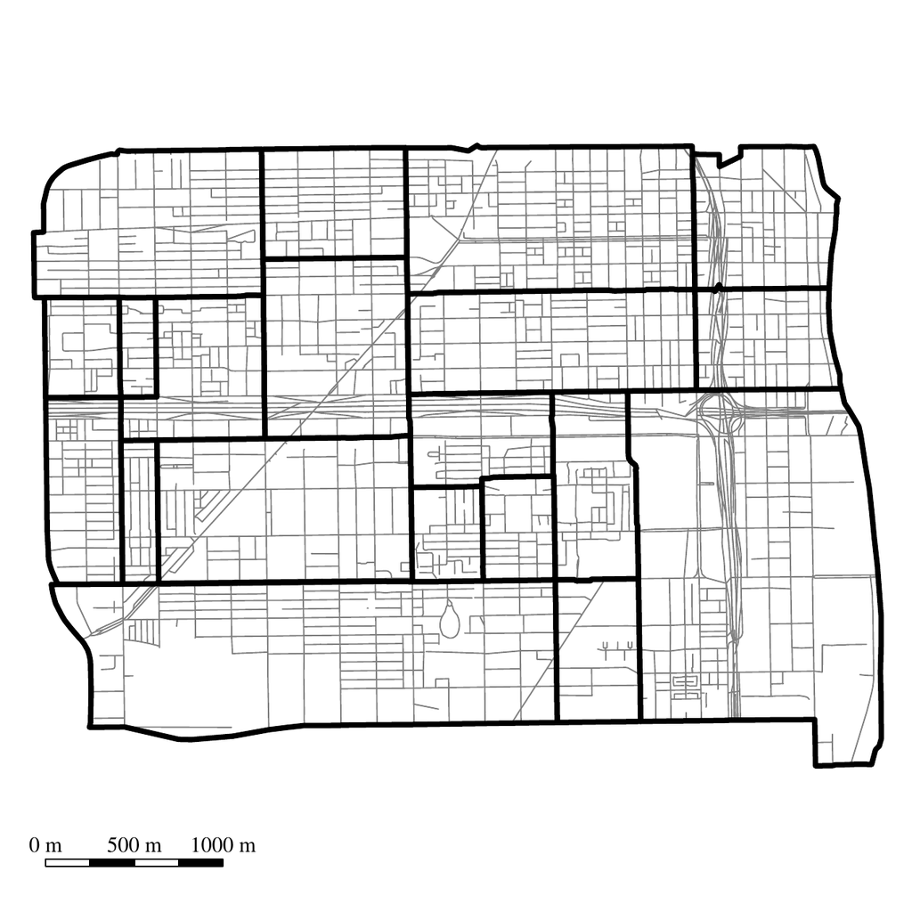

Figure 1: Road network (in gray) corresponding to the Near West Side Community Area of Chicago. Census tracts of the area are overlayed in black.

```r
> cook.tracts <- tracts(state = "Illinois", county = "031", class = "sp")
> class(cook.tracts)
[1] "SpatialPolygonsDataFrame"
attr(,"package")
[1] "sp"
> cook.network <- roads(state = "Illinois", county = "031", year = 2011,
                  class = "sp")
> class(cook.network)
[1] "SpatialLinesDataFrame"
attr(,"package")
[1] "sp"
```

The objects `cook.tracts` and `cook.network` are composed of 1319 polygons and 86227 lines, respectively (as of the end of June 2021). Now, both spatial objects are intersected to construct a smaller road network that corresponds to the Near West Side Community Area of Chicago.

```r
> names.tracts <- as.character(cook.tracts@data[,"NAME"])
> select.tracts <- c("8378","2804","8330","2801","2808","2809","8380",
                     "8381","8331","2819","2827","2828","8382","8329",
                     "2831","2832","8333","8419","8429","2838")
> cook.tracts.select <- cook.tracts[which(names.tracts%in%select.tracts),]
> chicago.SpLines <- intersect(cook.network, cook.tracts.select)
> length(chicago.SpLines)
[1] 1357
```

Object `chicago.SpLine` (`SpatialLinesDataFrame`) has 1357 lines. Then, this object’s coordinates are converted into UTM (Chicago’s UTM zone is 16):

```r
> chicago.SpLines <- spTransform(chicago.SpLines,
                                 "+proj=utm +zone=16 ellps=WGS84")
```

Now the corresponding `linnet` object is created:

```r
> chicago.linnet <- as.linnet(chicago.SpLines)
> chicago.linnet
Linear network with 10602 vertices and 11910 lines
Enclosing window:
    rectangle = [442564.6, 447320] x [4634170, 4637660] units
```

It is worth noting how the transformation of the network into a `linnet` object increases dramatically the number of line segments (from 1357 to 11910). This is a consequence of the fact that `SpatialLines` objects can handle curvilinear segments, made of multiple line segments, as a single line. However, `linnet` objects follow the definition of the linear network provided in the Introduction section, which excludes this possibility.

It is required that the network is fully connected to allow the computation of a distance between any pair of points. This can be checked with the function `connected`.

```r
> table(connected(chicago.linnet, what = "labels"))

    1     2     3     4     5     6     7     8     9
10575     5     2     2     2     5     2     2     7
```

This output indicates that there is a connected component of 10575 vertices and other eight components with only a few vertices. The use of `connected` with the option `what = "components"` enables us to extract the larger connected component for the analysis, discarding the others.

```r
> chicago.linnet.components <- connected(chicago.linnet,
                                         what = "components")
> chicago.linnet.components[[1]]
Linear network with 10575 vertices and 11891 lines
Enclosing window:
rectangle = [442564.6, 447320] x [4634170, 4637660]
units
> chicago.linnet <- chicago.linnet.components[[1]]
```

At this point, it is worth considering the possibility of reducing the network’s complexity. The function `SimplifyLinearNetwork` of *SpNetPrep* can be used for this purpose. A reasonable choice of the parameters is `Angle = 20` and `Length = 50` (Briz-Redón 2019). This choice of the parameters means that a pair of segments meeting at a second-degree vertex are merged into one single segment if the angle they form (measured from 0$^{\circ}$ to 90$^{\circ}$) is lower than 20$^{\circ}$ and if the length of each of them is lower than 50 m. Hence, the network’s complexity is reduced (in terms of the number of segments and lines) while its geometry is preserved. The following lines of code execute `SimplifyLinearNetwork` and redefine `chicago.SpLine` according to the structure of the final `linnet` object.

```r
> chicago.linnet <- SimplifyLinearNetwork(chicago.linnet,
                                          Angle = 20, Length = 50)
> chicago.linnet
Linear network with 3026 vertices and 4339 lines
Enclosing window:
rectangle = [442564.6, 447320] x [4634170, 4637660] units
> chicago.SpLines <- as.SpatialLines.psp(as.psp(chicago.linnet))
```

Thus, the final road network from Chicago that we use for the analysis has 4339 lines and 3026 vertices. An example of how `SimplifyLinearNetwork` reduces the network’s complexity is shown in Figure 2, which corresponds to a squared zone of Chicago’s network with a diameter of 600 m.

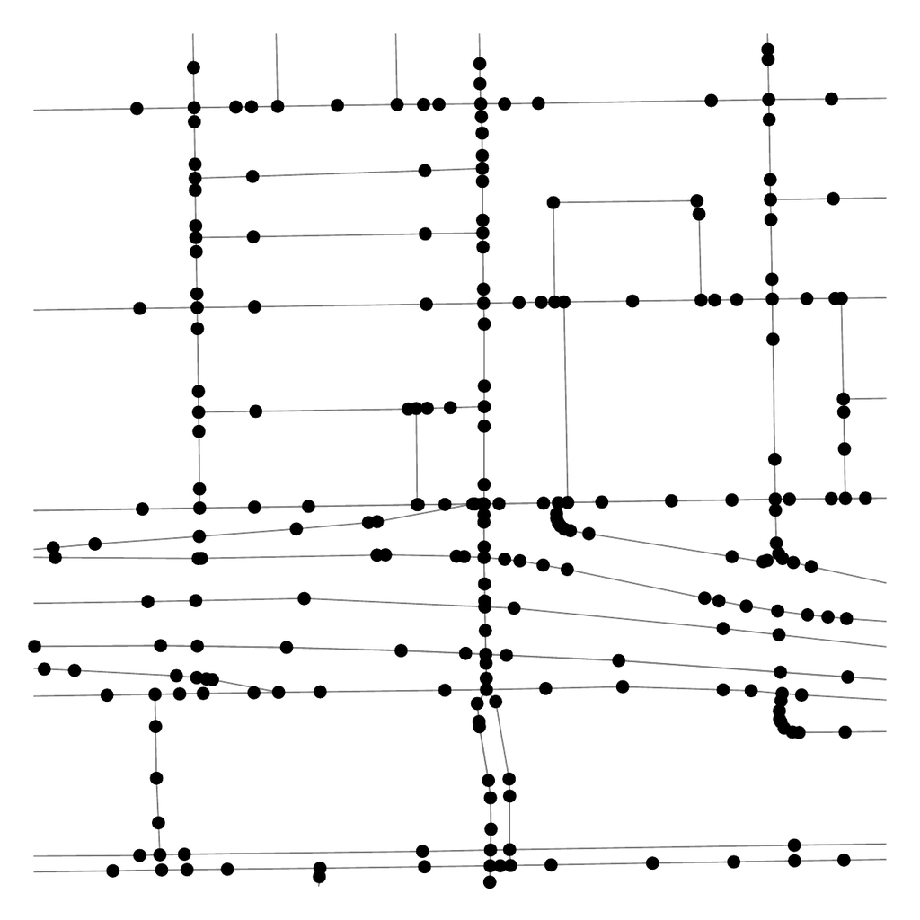

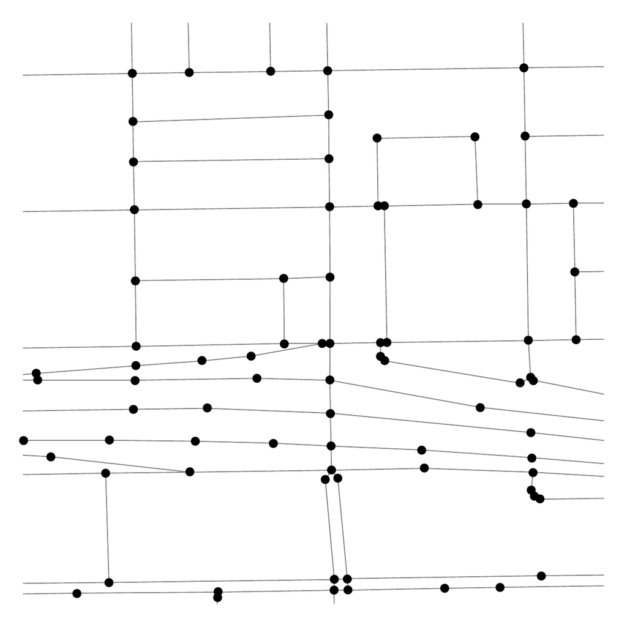

(a)

(b)

Figure 2: Extracting a part of the road network structure analyzed from Chicago. Original structure extracted (left), made of 285 lines and 272 vertices, and simplified version of it (right) with 122 lines and 109 vertices.

## Downloading and preparing crime data

Point-referenced crime datasets corresponding to several cities from the United States of America can be downloaded through the R package [*crimedata*](https://CRAN.R-project.org/package=crimedata) (Ashby 2019). Concretely, *crimedata* currently provides (as of June 2021) crime open data recorded in Austin, Boston, Chicago, Detroit, Fort Worth, Kansas City, Los Angeles, Louisville, Mesa, New York, San Francisco, Tucson, and Virginia Beach. Therefore, the function `get_crime_data` from this package can be used for downloading a dataset of crime events recorded in Chicago in the period 2007-2018.

```r
> chicago.crimes <- get_crime_data(years = 2007:2018, cities = "Chicago")
> dim(chicago.crimes)
[1] 39206    12
```

The year, month, and hour of occurrence of each crime can be extracted with the corresponding functions of the package [*lubridate*](https://CRAN.R-project.org/package=lubridate) (Grolemund and Wickham 2011).

```r
> chicago.crimes$year <- year(chicago.crimes$date_single)
> chicago.crimes$month <- month(chicago.crimes$date_single)
> chicago.crimes$hour <- hour(chicago.crimes$date_single)
```

Then, a marked point pattern lying on `chicago.linnet` can be created with function `lpp` to provide the framework required by the *DRHotNet* package. A `data.frame` is passed to `lpp` including the coordinates of the events (in UTM), the type of event according to the receiver of the offense (`offense_against`), and the year, month, and hour of occurrence that have been just computed.

```r
> chicago.crimes.coord <- data.frame(x = chicago.crimes$longitude,
                                     y = chicago.crimes$latitude)
> coordinates(chicago.crimes.coord) <-~ x + y
> lonlat_proj <- "+proj=longlat +datum=WGS84 +ellps=WGS84 +towgs84=0,0,0"
> utm_proj <- "+proj=utm +zone=16 ellps=WGS84"
> proj4string(chicago.crimes.coord) <- lonlat_proj
> chicago.crimes.coord <- spTransform(chicago.crimes.coord, utm_proj)
> X.chicago <- lpp(data.frame(x = chicago.crimes.coord@coords[,1],
                   y = chicago.crimes.coord@coords[,2],
                   offense_against = chicago.crimes$offense_against,
                   year = chicago.crimes$year,
                   month = chicago.crimes$month,
                   hour = chicago.crimes$hour),
                   chicago.linnet)
Warning message:
38006 points were rejected as lying outside the specified window
```

A total of 38006 points are rejected because they lie outside the road network. Hence, a marked point pattern of 1200 crimes that lie on `chicago.linnet` remains for the analysis. The four marks are categorical, presenting the following values and absolute frequencies:

```r
> table(X.chicago$data$offense_against)
other  persons property  society
   86      257      749      108
> table(X.chicago$data$year)
2007 2008 2009 2010 2011 2012 2013 2014 2015 2016 2017 2018
 126  131   97  111  100  110   87   84   76   93   92   93
> table(X.chicago$data$month)
  1   2   3   4   5   6   7   8   9  10  11  12
103  71 101  92 110 100 128 102 111 109  95  78
> table(X.chicago$data$hour)
 0  1  2  3  4  5  6  7  8  9 10 11 12 13 14 15 16 17
45 34 29 25 19 14 18 41 53 51 48 54 71 71 69 71 60 72
18 19 20 21 22 23
64 67 60 52 62 50
```

Hence, *DRHotNet* functionalities are now applicable to `X.chicago`. In the main example shown, the relative occurrence of crimes against persons along the road network included in `X.chicago` is analyzed. To this end, the functions of the package are used following the steps that have been established for the differential risk hotspot detection methodology previously described.

## Estimating a relative probability surface

The function `relpnet` of *DRHotNet* has to be used at first to estimate a relative probability surface over the linear network. As it has been explained, this implies estimating a relative probability in the middle point of each segment of the network.

```r
> rel_probs_persons <- relpnet(X = X.chicago,
                               lixel_length = 50,
                               h = 250,
                               mark = "offense_against",
                               category_mark = "persons")
```

The available parameter `finespacing` is by default set to `FALSE` in order to reduce the computational cost (as `FALSE` is the default value, it can be omitted in the specification of the function). If `finespacing` is set to `TRUE`, more accurate kernel density estimates are obtained at short segments, but the computational cost can become prohibitive. The interested reader can consult the documentation of the `densityHeat` function of *spatstat.linnet* to know precisely how this parameter works.

In this example, an upper bound of 50 m is chosen for the lixel length. This means that segments shorter than 50 m are not split, whereas those longer than 50 m are split into several shorter lixels of no more than 50 m lengths. This operation is performed internally by `relpnet` with the function `lixellate` from *spatstat.linnet*. The bandwidth parameter, $h$, is set to 250 m. The `mark` and `category_mark` parameters are used to specify the type of event that is under analysis.

The exploration of the object `rel_probs_persons` with function `str` allows the user to check that the choice of a 50 m threshold for the lixel length produces 8617 segments along the network. Thus, a relative probability is estimated in the middle point of each of these segments, which can be accessed by typing `$probs`:

```r
> str(rel_probs_persons)
List of 5
 $ probs        : num [1:8617] 0.129 0.138 0.202 0.492 0.662 ...
 $ lixel_length : num 50
 $ h        : num 250
 $ mark         : chr "offense_against"
 $ category_mark: chr "persons"
```

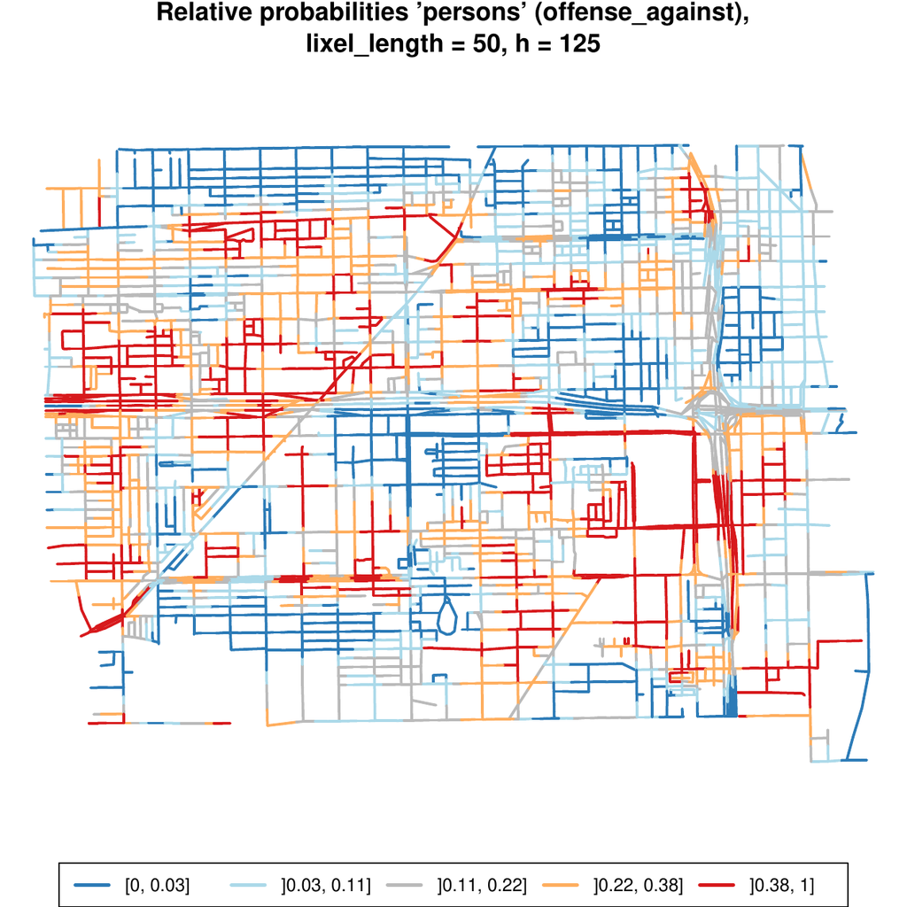

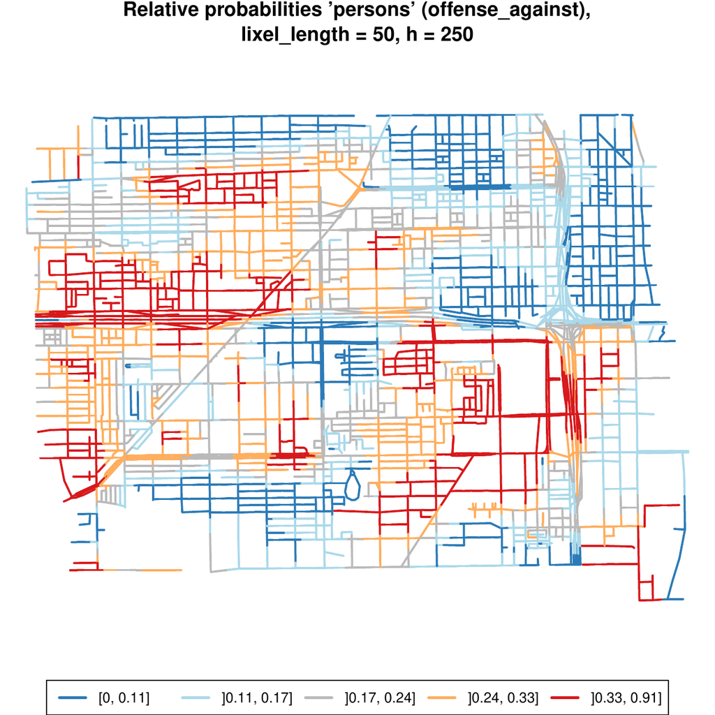

(a)

(b)

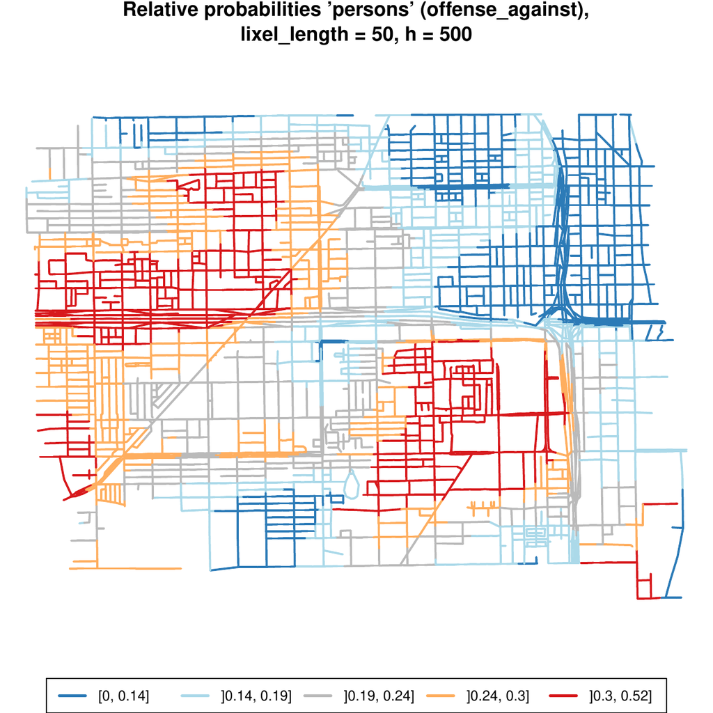

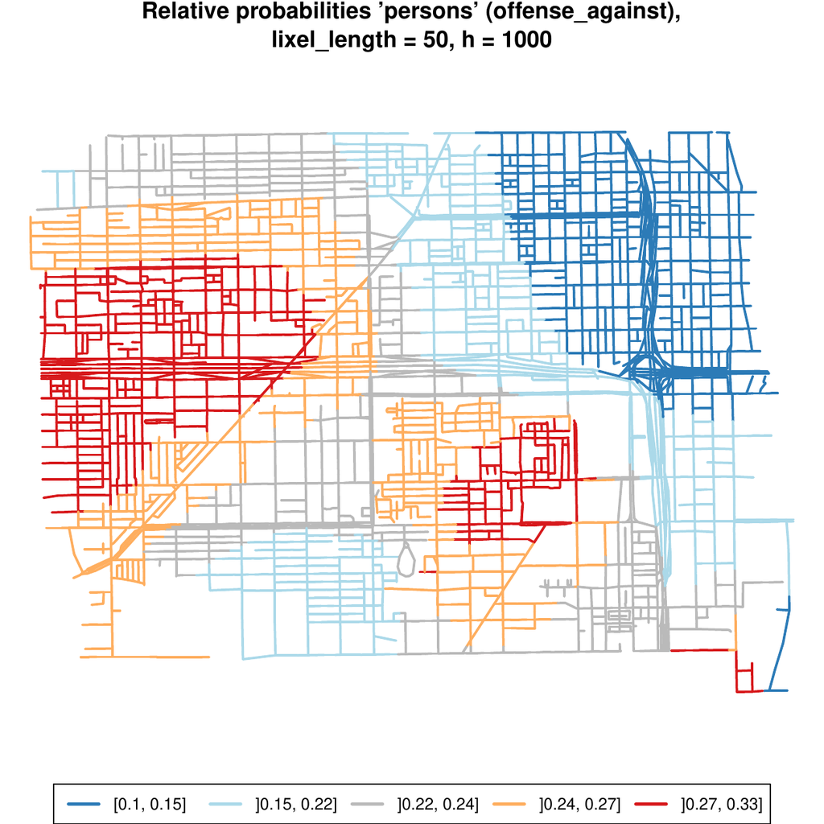

(c)

(d)

Figure 3: Outputs from the function `plotrelp` for the following choices of *h*: 125 (a), 250 (b), 500 (c) and 1000 (d).

In view of Figure 3, we consider that $h=250$ is a reasonable choice (although some procedures for bandwidth selection could be explored for taking this decision). Therefore, this selection of the bandwidth parameter is maintained to display now how the `drhot` function of the package works.